## Interpretación de la capacidad

| Para procesos | Bilateral | Unilateral |
| --- | --- | --- |
| … existentes | 1,33 | 1,25 |
| … nuevos | 1,50 | 1,45 |
| … críticos existentes | 1,50 | 1,45 |
| … críticos nuevos | 1,67 | 1,45 |

Montgomery, Douglas (2004). *Introduction to Statistical Quality Control*. New York, New York: John Wiley & Sons, Inc. p. 776

- En un proceso *Six Sigma*, el índice de capacidad debe ser superior o igual a 2.
- En cualquier caso, un índice de capacidad superior a 2,5 puede indicar un consumo excesivo de recursos en pro de la calidad y reflejar una oportunidad para la reducción de costes.
- Si *Cp* ≥ 1 y *Cpk* ≥ 1
  - El proceso es capaz, no necesita mejora.
- Si *Cp* > 1 y *Cpk* < 1
  - El proceso es capaz, pero requiere corrección para centrar los resultados.
- Si *Cp* < 1
  - El proceso no es capaz.
  - Se puede trabajar con un proceso incapaz, estableciendo un control 100% de las unidades fabricadas (control automático o manual).
  - Es aconsejable, rediseñar el proceso para reducir la variabilidad y aumentar la capacidad del proceso.

## Ejemplo

Se desea establecer la capacidad de una línea de envasado de un perfume en botellines de 50 ml. Los datos de las últimas muestras tomadas están en el archivo perfume.txt.

¿Es el proceso capaz si se ha establecido que el volumen debe estar entre 49,9 y 50,1 mL?

| 49,97 | 50,01 | 50,00 | 49,98 | 49,99 | 49,99 |
| --- | --- | --- | --- | --- | --- |
| 49,99 | 50,01 | 50,01 | 50,01 | 50,06 | 49,97 |
| 50,05 | 49,99 | 50,02 | 49,97 | 50,02 | 50,05 |
| 49,97 | 50,04 | 49,98 | 49,99 | 50,00 | 50,04 |
| 50,01 | 50,00 | 49,95 | 49,98 | 49,97 | 50,02 |
| 49,99 | 50,01 | 50,03 | 49,98 | 50,06 | 50,00 |
| 50,01 | 49,96 | 50,05 | 50,02 | 49,99 | 50,00 |
| 49,98 | 49,98 | 49,97 | 50,06 | 49,96 | 50,04 |
| 50,03 | 50,04 | 50,00 | 50,03 | 49,98 | 49,99 |
| 50,03 | 50,01 | 49,99 | 49,98 | 49,99 | 50,01 |

## Capacidad y número de defectos (en control)

El número de unidades no conformes con la especificación se establecen calculando la probablidad de obtener un valor superior a LSE o un valor inferior a LIE.

Para un proceso con ambos límites de especificación

$$P(nc) = P(x > LSE) + P(x < LIE) \\ \\
P(nc) = P(z > 3 C_{pk}) + P(z < -3 C_{pk})$$

Se suele indicar en DPMO (*defects per milion oportunities*).

## Otros índices de capacidad

Existen otros índices, de aplicación menos común que incorporan consideraciones adicionales sobre *Cp* y *Cpk*.

Pueden encontrarse descritos en la bibliografia. Por ejemplo, en

Kotz, S., & Johnson, N. L. (2002). Process capability indices—a review, 1992–2000. *Journal of quality technology*, 34(1), 2-19.

Wu, C. W., Pearn, W. L., & Kotz, S. (2009). An overview of theory and practice on process capability indices for quality assurance. *International journal of production economics*, 117(2), 338-359.

Senvar, O., & Tozan, H. (2010). Process capability and six sigma methodology including fuzzy and lean approaches. In *Products and Services; from R&D to Final Solutions*. InTech.

## Relación entre capacidad y control

En un proceso ideal…

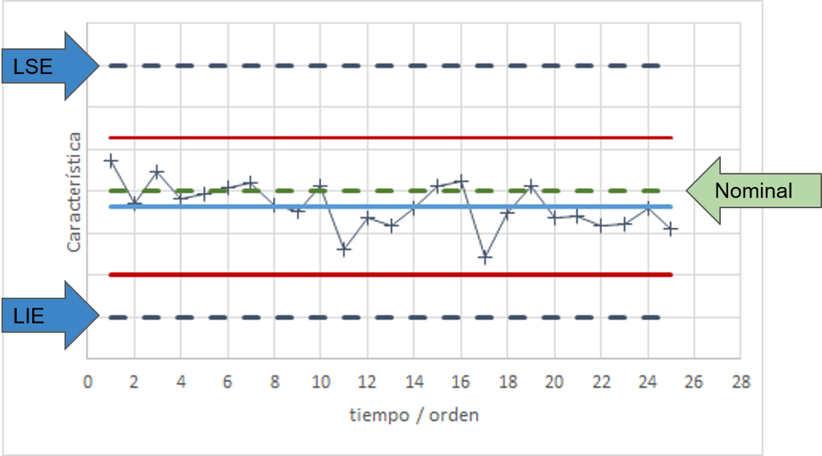

Debe tenerse en cuenta que:

- El proceso puede estar en control y no cumplir especificaciones.
- El proceso puede cumplir especificaciones y no estar en control.

¿Cómo serían en estos casos los gráficos de control de individuos (si añadimos las líneas de especificación)?

# Capacidad y rendimiento

## Límites de la capacidad

La capacidad definida, tal y como se ha discutido más arriba, incluye en el cálculo solo la variabilidad intragrupo o variabilidad natural. Por ello, debe interpretarse como la aptitud **potencial** del proceso para cumplir con los requerimientos del cliente (las especificaciones).

Si el proceso es estable y esta en control, esta es una medida adecuada y por ello, a veces, es denominada **capacidad a corto plazo**.

## Rendimiento o capacidad a largo plazo

Para describir, la aptitud del proceso para cumplir con las especificaciones de forma más **real** o **a largo plazo**, se establecen los índices *Pp* y *Ppk*. Estos se calculan usando la variabilidad calculada usando todas las observaciones del proceso, la variabilidad global, independientemente de si este está en control o no.

$$P_p = { {LSE - LIE} \over {6 \sigma_{global} } } \\ \\
P_{pk} = { {\min(LSE - \hat \mu ; \hat \mu - LIE)} \over {3 \sigma_{global} } }$$

Si se observa divergencia entre los valores de *Cpk* y *Ppk*, ello indica que el proceso no está bajo control estadístico.

Puede encontrarse más información en

- https://c.ymcdn.com/sites/casss.site-ym.com/resource/resmgr/CMC_No_Am_Jul_Spkr_Slds/2015_CMCS_DiMartinoMark.pdf
- http://blog.minitab.com/blog/michelle-paret/process-capability-statistics-cpk-vs-ppk

## Ejemplo

En un horno de una incineradora de residuos urbanos es quemado el contenido de los camiones que llegan con los residuos previamente seleccionados. La escoria producida por el horno como resultado de la combustión, es analizada en el laboratorio de control de calidad que para determinar su composición y supervisar que la combustión haya sido correcta.

Se sabe que una combustión correcta necesita que la temperatura del horno no sea inferior a 850 ºC. Para no incrementar los costes de combustible, se ha establecido que el horno debe trabajar entre 840 ºC y 860 ºC.

Hoy es su primer dia de trabajo como ingeniero y le encargan que supervise la temperatura del horno, entre otras cosas; para ello le entregan el registro de temperaturas de los últimos días (ver fichero horno.csv). El fichero que ha recibido tiene registrado la temperatura media del horno cada diez minutos.

Estudia la capacidad del proceso.

## Proporción de no conformes a largo plazo

Cunado el proceso está en control, el número de unidades no conformes con la especificación se establece como
$$\\P(nc) = P(z > 3 C_{pk}) + P(z < -3 C_{pk}) \\$$

A largo plazo y atendiendo que el proceso puede tener una deriva de 1,5 desviaciones estándar sin ser detectado como fuera de control, se considera la proporción de no conformes como
$$P(nc) = P(z > 3 C_{pk}-1,5) + \\ P(z < -3 C_{pk}-1,5)$$

https://www.isixsigma.com/new-to-six-sigma/dmaic/15-sigma-process-shift/

Rudisill, F., & Druley, S. (2004). Which Six Sigma Metric Should I Use?. *Quality Progress*, 37(3), 104.

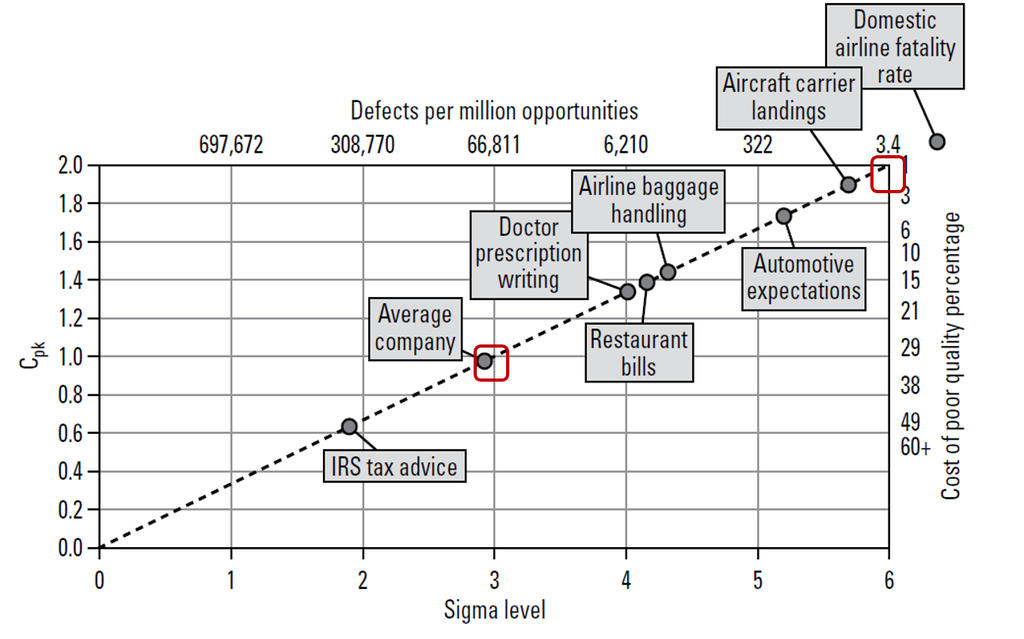

# Estimación de la capacidad en procesos no normales

## ¿Qué hacemos si los datos no están normalmente distribuidos?

En este caso, hay dos alternativas:

- usar estimadores no paramétricos para la dispersión (cuantiles),
- usar transformaciones de variables:
  - logaritmo, inversa, cuadrado…
  - transformada de Box-Cox (1964),
    - https://www.encyclopediaofmath.org/index.php/Box%E2%80%93Cox_transformation
  - transformada de Johnson (1949)
    - https://rexplorations.wordpress.com/2015/11/03/johnson-transformation-for-non-normal-data/

## Estimadores no parámetricos

A partir de los cuantiles de los datos o de la distribución que estos siguen, puede calcularse *Cp* y *Cpk* de acuerdo con las fórmulas siguientes

$$C_p = { {LSE - LIE} \over {X_{0,99865} - X_{0,00135}}}\\ \\
C_{pk} = \min \Bigg( { {LSE - X_{0,5}} \over {X_{0,99865} - X_{0,5} } } ; {X_{0,5} - LIE \over {X_{0,5} - X_{0,00135}}}\Bigg)$$

## Transformada de Box-Cox

La transformada de Box-Cox corresponde al cambio de variable siguiente
$$\\y_{i}^{(\lambda )} =
\begin{cases} \dfrac {y_{i}^{\lambda }-1} {\lambda} &\text{si }\lambda \neq 0
\\
\ln y_{i} &\text{si }\lambda =0\end{cases}$$

## Ejemplo

Transforma los datos de turbidez que siguen en un conjunto de datos que pueda provenir de una variable normalmente distribuida (adaptado de http://rcompanion.org/handbook/I_12.html)

```r
Turbidity <- c(1.0, 1.2, 1.1, 1.1, 2.4,
               2.2, 2.6, 4.1, 5.0, 10.0,
               4.0, 4.1, 4.2, 4.1, 5.1,
               4.5, 5.0, 15.2, 10.0, 20.0,
               1.1, 1.1, 1.2, 1.6, 2.2,
               3.0, 4.0, 10.5)
```

```r
ggplot(NULL, aes(x=Turbidity)) +
  geom_histogram(binwidth = 2,fill="lightgrey",color="black") +
  theme_classic()

ggplot(NULL, aes(sample=Turbidity)) +
  geom_qq() + geom_qq_line() +
  theme_classic()
```

[figure not shown]

```r
shapiro.test(Turbidity)
```

```
##
##  Shapiro-Wilk normality test
##
## data:  Turbidity
## W = 0.74633, p-value = 1.383e-05
```

```r
ad.test(Turbidity)
```

```
##
##  Anderson-Darling normality test
##
## data:  Turbidity
## A = 2.4582, p-value = 2.178e-06
```

```r
if(!require("MASS")) {
  install.packages("MASS", repos="https://cloud.r-project.org/",
         quiet=TRUE, type="binary")
  library("MASS")
}
```

```r
Box <- boxcox(Turbidity ~ 1,
             lambda = seq(-3,3,0.01)
             )
```

[figure not shown]

```r
Cox <- data.frame(Box$x, Box$y)
Cox2 <- Cox[with(Cox, order(-Cox$Box.y)),]
Cox2[1,]
```

```
##     Box.x     Box.y
## 283 -0.18 -41.35336
```

```r
lambda <- Cox2[1, "Box.x"]

if(lambda == 0) {
  T_box <- log(Turbidity)
} else {
  T_box <- (Turbidity ^ lambda - 1)/lambda
}
```

```r
ggplot(NULL, aes(x=T_box)) +
  geom_histogram(binwidth = 2,fill="lightgrey",color="black") +
  theme_classic()

ggplot(NULL, aes(sample=T_box)) +
  geom_qq() + geom_qq_line() +
  theme_classic()
```

[figure not shown]

```r
shapiro.test(T_box)
```

```
##
##  Shapiro-Wilk normality test
##
## data:  T_box
## W = 0.93352, p-value = 0.07565
```

```r
ad.test(T_box)
```

```
##
##  Anderson-Darling normality test
##
## data:  T_box
## A = 0.66162, p-value = 0.07526
```

## Transformada de Johnson

```r
if(!require("Johnson")) {
  install.packages("Johnson", repos="https://cloud.r-project.org/",
         quiet=TRUE, type="binary")
  library("Johnson")
}
```

```r
John <- RE.Johnson(Turbidity)
T_johnson <- John$transformed
```

```r
ggplot(NULL, aes(x=T_johnson)) +
  geom_histogram(binwidth = 2,fill="lightgrey",color="black") +
  theme_classic()

ggplot(NULL, aes(sample=T_johnson)) +
  geom_qq() + geom_qq_line() +
  theme_classic()
```

[figure not shown]

```r
shapiro.test(T_johnson)
```

```
##
##  Shapiro-Wilk normality test
##
## data:  T_johnson
## W = 0.93547, p-value = 0.08481
```

```r
ad.test(T_johnson)
```

```
##
##  Anderson-Darling normality test
##
## data:  T_johnson
## A = 0.61889, p-value = 0.09664
```

# Referencias normativas

- ASTM E2281-15. Standard Practice for Process Capability and Performance Measurement. https://www.astm.org/Standards/E2281.htm
- AIAG (Automotive Industry Action Group). Statistical Process Control. Reference Manual. http://www.aiag.org/
- ISO 22514-2:2017. Statistical methods in process management – Capability and performance – Part 2: Process capability and performance of time-dependent process models https://www.iso.org/standard/71617.html
- UNE-ISO 22514-1:2017. Métodos estadísticos en la gestión de procesos. Capacidad y rendimiento. Parte 1: Principios y conceptos generales. https://www.une.org/encuentra-tu-norma/busca-tu-norma/norma/?c=N0057911